# AnalisisAIRBNB

Grupo 12

2024-10-06

## Introducción y definición de objetivos

Durante estos últimos años, plataformas donde de reservan propiedades durante un tiempo determinado, como es Airbnb, ha ido subiendo su popularidad y mucha gente opta por este tipo de servicio. Es por ello que un análisis de este modelo de negocio es interesante tanto para los clientes como para la empresa propietaria de Airbnb. Por ello, el objetivo de esta investigación es observar como afecta el precio a las distintas variables.

Hemos descartado algunas variables dentro de esta base de datos. La primera es la variable bed_type, la cual descartamos ya que, tras hacer análisis previos, realmente no llevaría a cabo ningún cambio debido a que la gran mayoria son del mismo tipo (real bed). Las siguientes variables que hemos descartado son la de “latitud”, “longitud” y “zipcode”, ya que tienen que ver con la localización de la propiedad y eso ya se refleja con las variables “city” y “neighbourhood”. Otra variable descartada es “amenities” ya que aparecerían muchas más variables que complejizarían el análisis y no aportaria a los objetivos propuestos. Con la variable “accomodates”, la cual se refiere al número de personas que se permite en la propiedad, se descartó ya que no influiría en un cambio significativo en las dems variables, como por ejemplo la del precio, ya que sean las personas que sean el precio por habitación será el mismo. Además que con la información del número de camas se puede aproximar. La variable “host_response_rate” (la tasa de respuesta del anfitrión) la descartamos ya que en muchos de los casos no hay información. Las variables como “first review” (fecha en que se realizó la primera valoración), “last review” (fecha en que se realizó la última valoración), “description” (la descripcion), “host_has_profile_pic” (si el anfitrión tiene foto de perfil en Airbnb), “host_since” (fecha cuando se publicó por primera vez la propiedad), “name” (nombre de la propiedad) o “thumbnail_url” (URL de la página de la habitación) las hemos descartado porque no son relevantes para nuestro análisis o directamente no se pueden analizar.

## Importacion de datos y paquetes usados

```r
library(dplyr)
library(readr)
library(tidyverse)
library(ggplot2)
library(summarytools)
library(GGally)
library(knitr)
library(ggcorrplot)
library(corrplot)
library(htmltools)

Airbnb_Data <- read.csv("~/ESTADISTICA/Practica Grupal/AnalisisAIRBNB/Airbnb_Data.csv")
```

## Análisis exploratorio de datos

Vamos a realizar el estudio de todas las variables de los datos. Vamos a dividir el estudio en dos partes: análisis univariante y análisis bivariante.

### Análisis univariante:

#### Estudio de la variable price

Antes de estudiar la variable price, observamos que esta variable se encuentra de forma logarítmica, por tanto, no nos viene bien para el análisis. Simplemente invertiremos el logaritmo para obtener precios con más sentido.

```r
Airbnb_Data$log_price = exp(Airbnb_Data$log_price)
```

Ahora sí que realizaremos el análisis de price.

CONTAR EL NÚMERO DE RESPUESTAS

```r
num_respuestas_PRICE <- length(unique(Airbnb_Data$log_price))
cat("La cantidad de respuestas obtenidas es:", num_respuestas_PRICE)
```

```
## La cantidad de respuestas obtenidas es: 767
```

Como podemos observar, no tiene sentido realizar un estudio de esta variable continua.

HISTOGRAMA DE PRECIOS

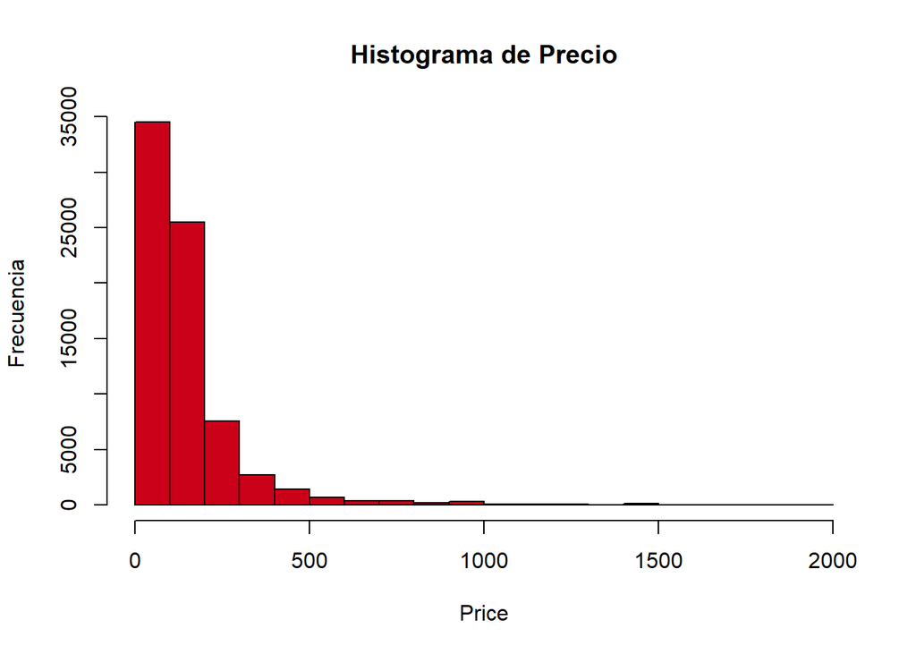

```r
hist(Airbnb_Data$log_price, col = "#CB0019", main = "Histograma de Precio", xlab = "Price", ylab = "Frecuencia", border = "black")
```

RESUMEN DE PRECIOS

```r
Airbnb_Data |> select(log_price) |> descr() |> kable(digits = 2)
```

|  | log_price |
| --- | --- |
| Mean | 160.37 |
| Std.Dev | 168.58 |
| Min | 1.00 |
| Q1 | 75.00 |
| Median | 111.00 |
| Q3 | 185.00 |
| Max | 1999.00 |
| MAD | 68.20 |
| IQR | 110.00 |
| CV | 1.05 |
| Skewness | 4.30 |
| SE.Skewness | 0.01 |
| Kurtosis | 26.55 |
| N.Valid | 74111.00 |
| Pct.Valid | 100.00 |

#### Estudio de la variable property_type

CONTAR EL NÚMERO DE RESPUESTAS

```r
num_respuestas_TYPE <- length(unique(Airbnb_Data$property_type))
cat("La cantidad de respuestas obtenidas es:", num_respuestas_TYPE)
```

```
## La cantidad de respuestas obtenidas es: 35
```

Como podemos observar, aquí si tiene sentido realizar un estudio para poder ver que tipo de casa es la que más se oferta

TABLA DE FRECUENCIAS

```r
tabla_frecuencias_type <- Airbnb_Data |>
     count(property_type) |>
    mutate(f = n / nrow(Airbnb_Data), N = cumsum(n), F = cumsum(f))

tabla_frecuencias_ordenada3 <- tabla_frecuencias_type |>
    arrange(desc(n))

tabla_frecuencias_ordenada3$F <- cumsum(tabla_frecuencias_ordenada3$f)

tabla_frecuencias_ordenada3$N <- cumsum(tabla_frecuencias_ordenada3$n)

print(tabla_frecuencias_ordenada3)
```

```
##         property_type     n            f     N         F
## 1           Apartment 49003 6.612109e-01 49003 0.6612109
## 2               House 16511 2.227874e-01 65514 0.8839983
## 3         Condominium  2658 3.586512e-02 68172 0.9198634
## 4           Townhouse  1692 2.283062e-02 69864 0.9426941
## 5                Loft  1244 1.678563e-02 71108 0.9594797
## 6               Other   607 8.190417e-03 71715 0.9676701
## 7          Guesthouse   498 6.719650e-03 72213 0.9743898
## 8     Bed & Breakfast   462 6.233892e-03 72675 0.9806237
## 9            Bungalow   366 4.938538e-03 73041 0.9855622
## 10              Villa   179 2.415296e-03 73220 0.9879775
## 11               Dorm   142 1.916045e-03 73362 0.9898935
## 12        Guest suite   123 1.659673e-03 73485 0.9915532
## 13          Camper/RV    94 1.268368e-03 73579 0.9928216
## 14          Timeshare    77 1.038982e-03 73656 0.9938606
```

[output cut: 21 more lines]

GRAFICO DE BARRAS CON FRECUENCIA RELATIVA DE PROPERTY_TYPE

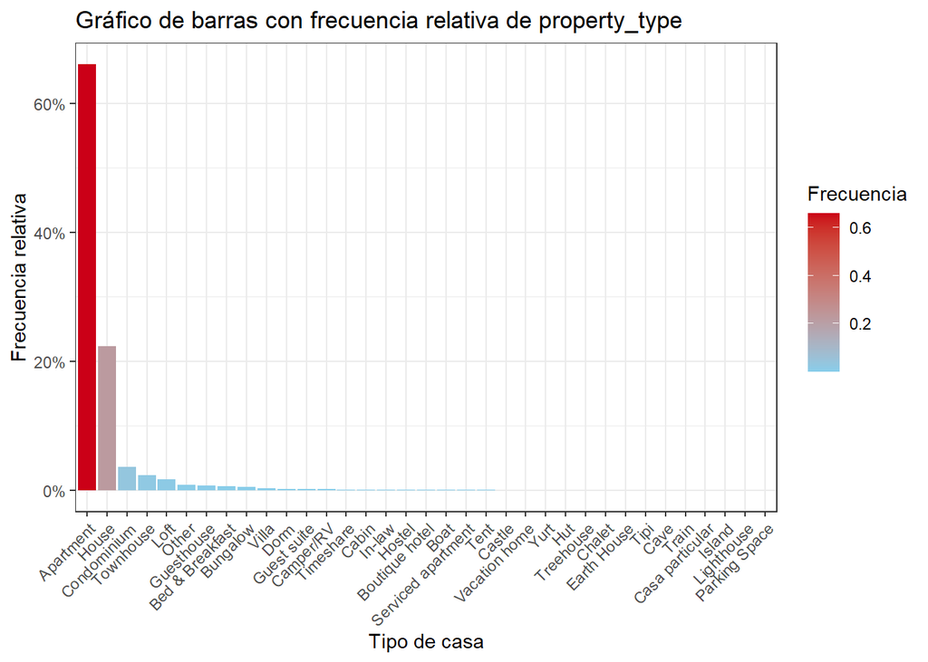

```r
Airbnb_Data |> group_by(property_type) |> summarise(Frequency = n()) |> mutate(Frequency = Frequency/sum(Frequency), property_type = reorder(property_type, -Frequency)) |> ggplot(aes(x = property_type, y = Frequency)) + geom_bar(stat = "identity", aes(fill = Frequency)) + scale_y_continuous(labels = scales::percent) + theme_bw() + labs(title = "Gráfico de barras con frecuencia relativa de property_type", x = "Tipo de casa", y = "Frecuencia relativa") + scale_fill_gradient("Frecuencia", low = "skyblue", high = "#CB0017") + theme(axis.text.x = element_text(angle = 45, hjust = 1))
```

GRAFICO DE BARRAS CON FRECUENCIA ABSOLUTA DE PROPERTY_TYPE

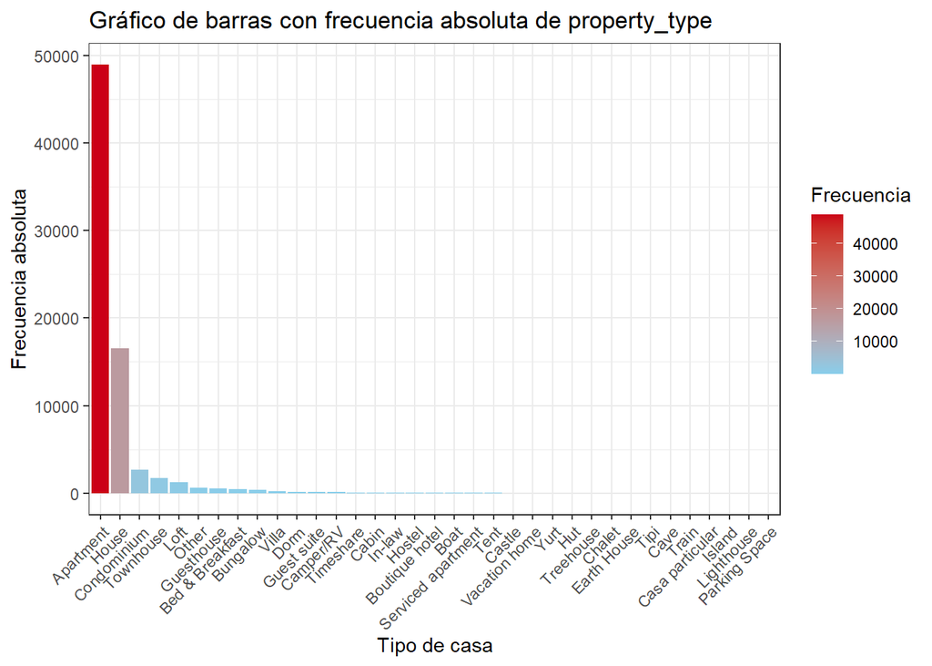

```r
Airbnb_Data |>
     group_by(property_type) |>
     summarise(Frequency = n()) |>
     mutate(property_type = reorder(property_type, -Frequency)) |>
    ggplot(aes(x = property_type, y = Frequency)) +
     geom_bar(stat = "identity", aes(fill = Frequency)) +
     theme_bw() +
     labs(title = "Gráfico de barras con frecuencia absoluta de property_type",
          x = "Tipo de casa",
          y = "Frecuencia absoluta") +
     scale_fill_gradient("Frecuencia", low = "skyblue", high = "#CB0017") +
    theme(axis.text.x = element_text(angle = 45, hjust = 1))
```

#### Estudio de la variable room_type

CONTAR EL NUMERO DE RESPUESTAS

```r
num_respuestas_TYPE <- length(unique(Airbnb_Data$room_type))
cat("La cantidad de respuestas obtenidas es:", num_respuestas_TYPE)
```

```
## La cantidad de respuestas obtenidas es: 3
```

FRECUENCIAS RELATIVAS Y ABSOLUTAS

```r
tabla_frecuencias_type <- Airbnb_Data |>
     count(room_type) |>
    mutate(f = n / nrow(Airbnb_Data), N = cumsum(n), F = cumsum(f))
 tabla_frecuencias_ordenada3 <- tabla_frecuencias_type |>
    arrange(desc(n))
 tabla_frecuencias_ordenada3$F <- cumsum(tabla_frecuencias_ordenada3$f)
 tabla_frecuencias_ordenada3$N <- cumsum(tabla_frecuencias_ordenada3$n)
 print(tabla_frecuencias_ordenada3)
```

```
##         room_type     n          f     N         F
## 1 Entire home/apt 41310 0.55740713 41310 0.5574071
## 2    Private room 30638 0.41340692 71948 0.9708140
## 3     Shared room  2163 0.02918595 74111 1.0000000
```

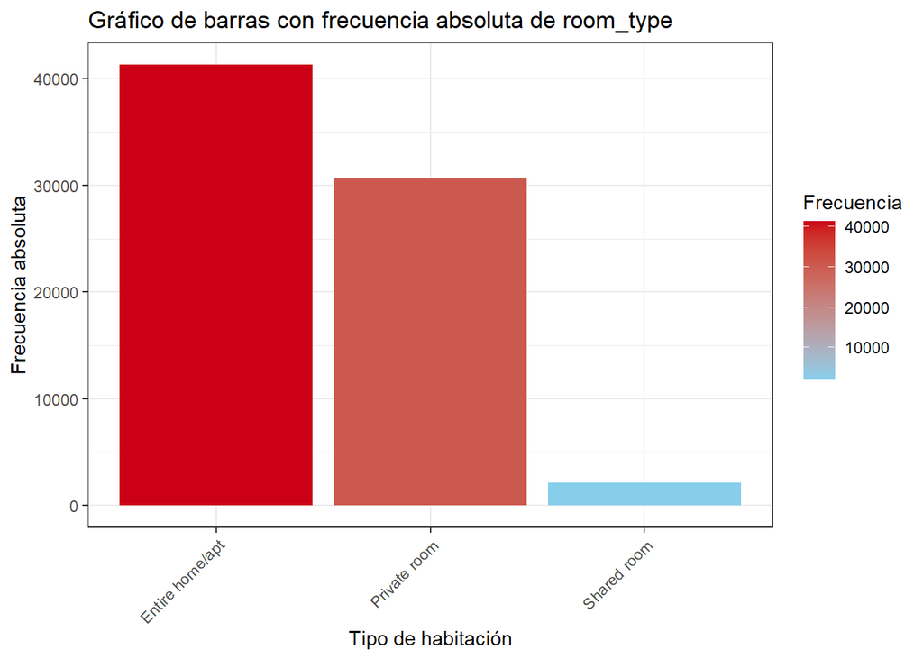

```r
Airbnb_Data |>
     group_by(room_type) |>
     summarise(Frequency = n()) |>
     mutate(room_type = reorder(room_type, -Frequency)) |>
     ggplot(aes(x = room_type, y = Frequency)) +
     geom_bar(stat = "identity", aes(fill = Frequency)) +
     theme_bw() +
     labs(title = "Gráfico de barras con frecuencia absoluta de room_type",
          x = "Tipo de habitación",
          y = "Frecuencia absoluta") +
     scale_fill_gradient("Frecuencia", low = "skyblue", high = "#CB0017") +
     theme(axis.text.x = element_text(angle = 45, hjust = 1))
```

GRAFICO DE BARRAS CON FRECUENCIA ABSOLUTA DE ROOM_TYPE

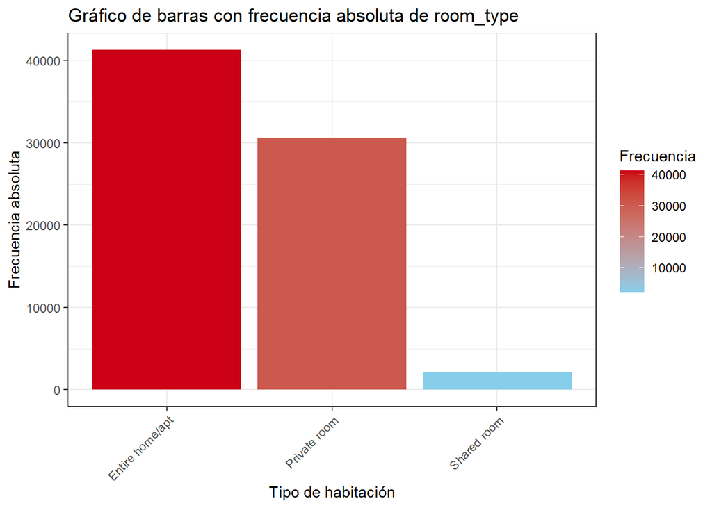

```r
Airbnb_Data |>
     group_by(room_type) |>
     summarise(Frequency = n()) |>
     mutate(room_type = reorder(room_type, -Frequency)) |>
     ggplot(aes(x = room_type, y = Frequency)) +
     geom_bar(stat = "identity", aes(fill = Frequency)) +
     theme_bw() +
     labs(title = "Gráfico de barras con frecuencia absoluta de room_type",
          x = "Tipo de habitación",
          y = "Frecuencia absoluta") +
     scale_fill_gradient("Frecuencia", low = "skyblue", high = "#CB0017") +
     theme(axis.text.x = element_text(angle = 45, hjust = 1))
```

#### Estudio de la variable bathrooms

CONTAR EL NUMERO DE RESPUESTAS

```r
num_respuestas_Bathrooms <- length(unique(Airbnb_Data$bathrooms))
cat("La cantidad de respuestas obtenidas es:", num_respuestas_Bathrooms)
```

```
## La cantidad de respuestas obtenidas es: 18
```

FRECUENCIAS RELATIVAS Y ABSOLUTAS

```r
tabla_frecuencias_bathrooms <- Airbnb_Data |>
     count(bathrooms) |>
     mutate(f = n / nrow(Airbnb_Data), N = cumsum(n), F = cumsum(f))
 tabla_frecuencias_ordenada4 <- tabla_frecuencias_bathrooms |>
     arrange(desc(n))
 tabla_frecuencias_ordenada4$F <- cumsum(tabla_frecuencias_ordenada4$f)
 tabla_frecuencias_ordenada4$N <- cumsum(tabla_frecuencias_ordenada4$n)
 print(tabla_frecuencias_ordenada4)
```

```
##    bathrooms     n            f     N         F
## 1        1.0 58099 7.839457e-01 58099 0.7839457
## 2        2.0  7936 1.070826e-01 66035 0.8910283
## 3        1.5  3801 5.128793e-02 69836 0.9423163
## 4        2.5  1567 2.114396e-02 71403 0.9634602
## 5        3.0  1066 1.438383e-02 72469 0.9778440
## 6        3.5   429 5.788614e-03 72898 0.9836327
## 7        4.0   286 3.859076e-03 73184 0.9874917
## 8        0.5   209 2.820094e-03 73393 0.9903118
## 9         NA   200 2.698655e-03 73593 0.9930105
## 10       0.0   198 2.671668e-03 73791 0.9956822
## 11       4.5   116 1.565220e-03 73907 0.9972474
## 12       5.0    72 9.715157e-04 73979 0.9982189
## 13       8.0    41 5.532242e-04 74020 0.9987721
## 14       5.5    39 5.262377e-04 74059 0.9992983
## 15       6.0    24 3.238386e-04 74083 0.9996222
## 16       6.5    12 1.619193e-04 74095 0.9997841
## 17       7.0    10 1.349327e-04 74105 0.9999190
## 18       7.5     6 8.095964e-05 74111 1.0000000
```

HISTOGRAMA SEGUN NUMERO DE BAÑOS

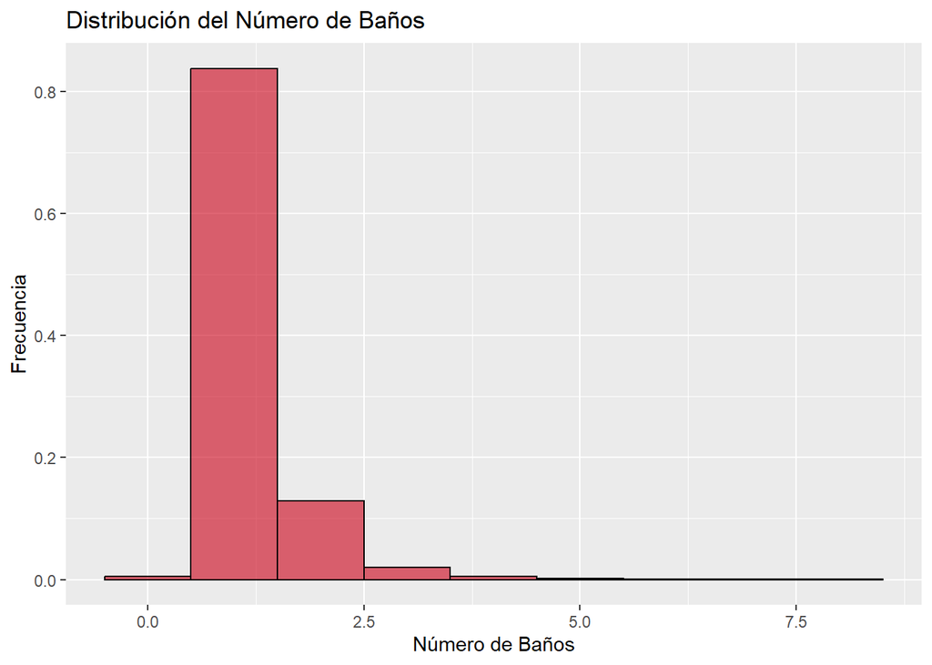

```r
datos <- Airbnb_Data$bathrooms
ggplot(data.frame(x = datos), aes(x = x)) +
     geom_histogram(binwidth = 1, fill = "#CB0017", color = "black",
                    aes(y = ..density..), alpha = 0.6) +
     stat_function(fun = dnorm, args = list(mean = mean(datos),  sd = sd(datos)), color = "#CB0019", size = 1.5) +
     labs(title = "Distribución del Número de Baños",
         x = "Número de Baños",
         y = "Frecuencia")
```

ANÁLISIS NÚMERICO

```r
Airbnb_Data |> select(bathrooms) |> descr() |> kable(digits = 2)
```

|  | bathrooms |
| --- | --- |
| Mean | 1.24 |
| Std.Dev | 0.58 |
| Min | 0.00 |
| Q1 | 1.00 |
| Median | 1.00 |
| Q3 | 1.00 |
| Max | 8.00 |
| MAD | 0.00 |
| IQR | 0.00 |
| CV | 0.47 |
| Skewness | 3.69 |
| SE.Skewness | 0.01 |
| Kurtosis | 22.23 |
| N.Valid | 73911.00 |
| Pct.Valid | 99.73 |

#### Estudio de la variable bed_type

CONTAR EL NUMERO DE RESPUESTAS

```r
num_respuestas_bed_type <- length(unique(Airbnb_Data$bed_type))
cat("El número de respuestas obtenido es: ", num_respuestas_bed_type)
```

```
## El número de respuestas obtenido es:  5
```

TABLA DE FRECUENCIAS

```r
tabla_frec_bed_type <- Airbnb_Data |> count(bed_type) |> mutate (f = n/nrow(Airbnb_Data), N = cumsum(n), F = cumsum(f))
tabla_frec_ord_5 <- tabla_frec_bed_type |> arrange(desc(n))
tabla_frec_ord_5$N <- cumsum(tabla_frec_ord_5$n)
tabla_frec_ord_5$F <- cumsum(tabla_frec_ord_5$f)
print(tabla_frec_ord_5)
```

```
##        bed_type     n           f     N         F
## 1      Real Bed 72028 0.971893511 72028 0.9718935
## 2         Futon   753 0.010160435 72781 0.9820539
## 3 Pull-out Sofa   585 0.007893565 73366 0.9899475
## 4        Airbed   477 0.006436292 73843 0.9963838
## 5         Couch   268 0.003616197 74111 1.0000000
```

GRAFICO DE BARRAS CON FRECUENCIA RELATIVA

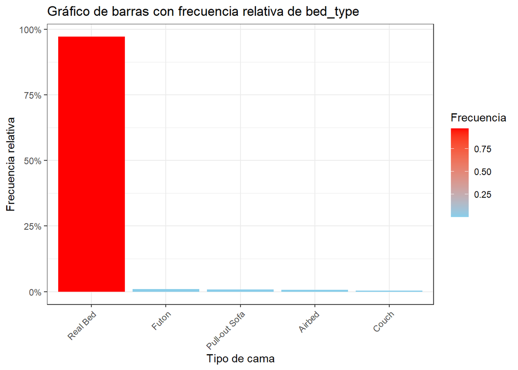

```r
Airbnb_Data  |> group_by(bed_type) |>  summarise(Frequency = n()) |> mutate(Frequency = Frequency/sum(Frequency), bed_type = reorder(bed_type, -Frequency)) |> ggplot(aes(x = bed_type, y = Frequency)) + geom_bar(stat = "identity", aes(fill = Frequency)) + scale_y_continuous(labels = scales::percent) + theme_bw() + labs(title = "Gráfico de barras con frecuencia relativa de bed_type", x = "Tipo de cama", y = "Frecuencia relativa") + scale_fill_gradient("Frecuencia", low = "skyblue", high = "red") + theme(axis.text.x = element_text(angle = 45, hjust = 1))
```

GRAFICO DE BARRAS CON FRECUENCIA ABSOLUTA

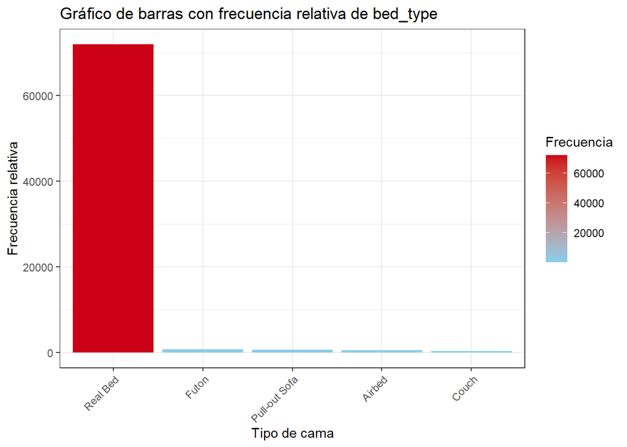

```r
Airbnb_Data  |> group_by(bed_type) |>  summarise(Frequency = n()) |> mutate(bed_type = reorder(bed_type, -Frequency)) |> ggplot(aes(x = bed_type, y = Frequency)) + geom_bar(stat = "identity", aes(fill = Frequency)) + theme_bw() + labs(title = "Gráfico de barras con frecuencia relativa de bed_type", x = "Tipo de cama", y = "Frecuencia relativa") + scale_fill_gradient("Frecuencia", low = "skyblue", high = "#CB0017") + theme(axis.text.x = element_text(angle = 45, hjust = 1))
```

#### Estudio de la variable cancellation_policy

CONTAR EL NUMERO DE RESPUESTAS

```r
num_respuestas_cancellation_policy <- length(unique(Airbnb_Data$cancellation_policy))
cat("El número de respuestas es: ", num_respuestas_cancellation_policy)
```

```
## El número de respuestas es:  5
```

FRECUENCIAS RELATIVAS Y ABSOLUTAS

```r
tabla_frec_cancellation_policy <- Airbnb_Data |> count(cancellation_policy) |> mutate(f = n/nrow(Airbnb_Data), N = cumsum(n), F = cumsum(f))
tabla_frec_ord_6 <- tabla_frec_bed_type |> arrange(desc(n))
tabla_frec_ord_6$N <- cumsum(tabla_frec_ord_6$n)
tabla_frec_ord_6$F <- cumsum(tabla_frec_ord_6$f)
print(tabla_frec_cancellation_policy)
```

```
##   cancellation_policy     n            f     N         F
## 1            flexible 22545 0.3042058534 22545 0.3042059
## 2            moderate 19063 0.2572222747 41608 0.5614281
## 3              strict 32374 0.4368312396 73982 0.9982594
## 4     super_strict_30   112 0.0015112466 74094 0.9997706
## 5     super_strict_60    17 0.0002293857 74111 1.0000000
```

GRAFICO DE BARRAS CON FRECUENCIA RELATIVA

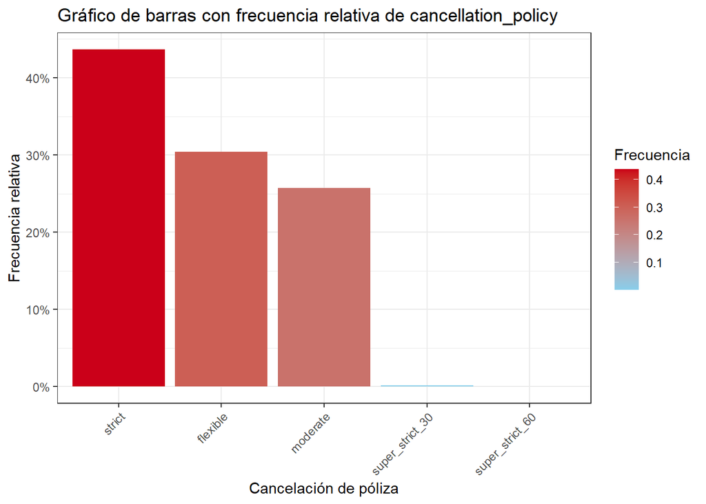

```r
Airbnb_Data  |> group_by(cancellation_policy) |>  summarise(Frequency = n()) |> mutate(Frequency = Frequency/sum(Frequency), cancellation_policy = reorder(cancellation_policy, -Frequency)) |> ggplot(aes(x = cancellation_policy, y = Frequency)) + geom_bar(stat = "identity", aes(fill = Frequency)) + scale_y_continuous(labels = scales::percent) + theme_bw() + labs(title = "Gráfico de barras con frecuencia relativa de cancellation_policy", x = "Cancelación de póliza", y = "Frecuencia relativa") + scale_fill_gradient("Frecuencia", low = "skyblue", high = "#CB0019") + theme(axis.text.x = element_text(angle = 45, hjust = 1))
```

GRAFICO DE BARRAS CON FRECUENCIA ABSOLUTA

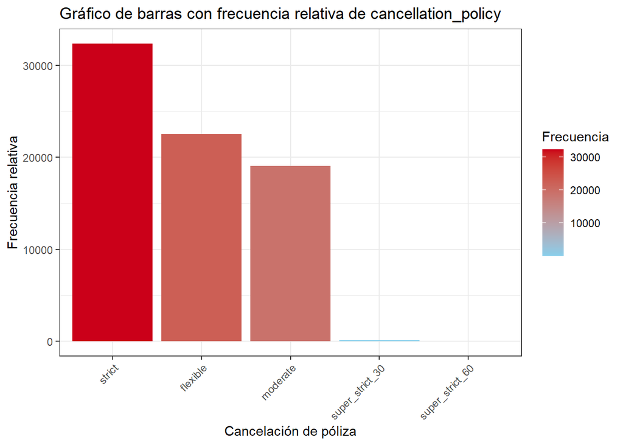

```r
Airbnb_Data  |> group_by(cancellation_policy) |>  summarise(Frequency = n()) |> mutate(cancellation_policy = reorder(cancellation_policy, -Frequency)) |> ggplot(aes(x = cancellation_policy, y = Frequency)) + geom_bar(stat = "identity", aes(fill = Frequency)) + theme_bw() + labs(title = "Gráfico de barras con frecuencia relativa de cancellation_policy", x = "Cancelación de póliza", y = "Frecuencia relativa") + scale_fill_gradient("Frecuencia", low = "skyblue", high = "#CB0019") + theme(axis.text.x = element_text(angle = 45, hjust = 1))
```

#### Estudio de la variable cleaning_fee

CONTAR EL NUMERO DE RESPUESTAS

```r
num_respuestas_cleaning_fee <- length(unique(Airbnb_Data$cleaning_fee))
cat("El número de respuestas obtenido es: ", num_respuestas_cleaning_fee)
```

```
## El número de respuestas obtenido es:  2
```

FRECUENCIAS RELATIVAS Y ABSOLUTAS

```r
tabla_frec_cleaning_fee <- Airbnb_Data |> count(cleaning_fee) |> mutate(f = n/nrow(Airbnb_Data), N = cumsum(n), F = cumsum(f))
tabla_frec_ord_7 <- tabla_frec_cleaning_fee |> arrange(desc(n))
tabla_frec_ord_7$N <- cumsum(tabla_frec_ord_7$n)
tabla_frec_ord_7$F <- cumsum(tabla_frec_ord_7$f)
print(tabla_frec_cleaning_fee)
```

```
##   cleaning_fee     n         f     N         F
## 1        False 19708 0.2659254 19708 0.2659254
## 2         True 54403 0.7340746 74111 1.0000000
```

GRAFICO DE BARRAS CON FRECUENCIA RELATIVA

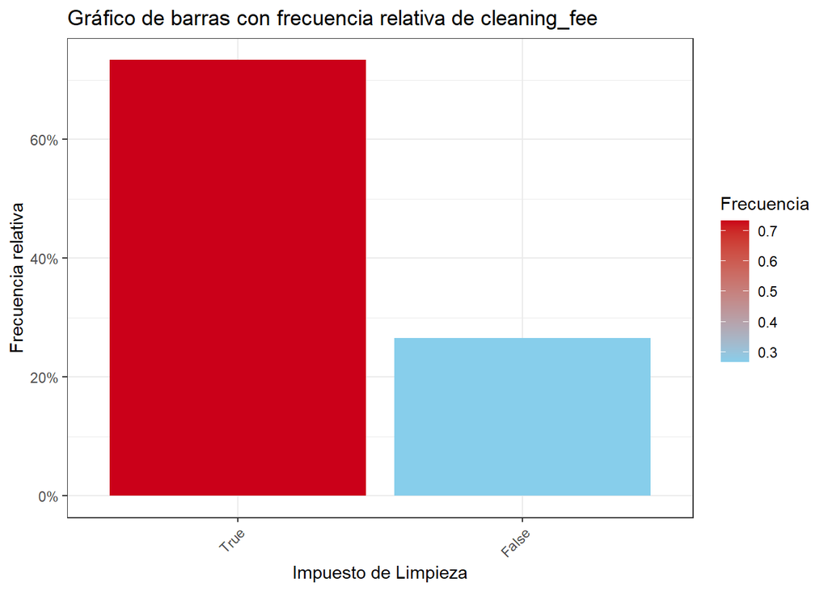

```r
Airbnb_Data  |> group_by(cleaning_fee) |>  summarise(Frequency = n()) |> mutate(Frequency = Frequency/sum(Frequency), cleaning_fee = reorder(cleaning_fee, -Frequency)) |> ggplot(aes(x = cleaning_fee, y = Frequency)) + geom_bar(stat = "identity", aes(fill = Frequency)) + scale_y_continuous(labels = scales::percent) + theme_bw() + labs(title = "Gráfico de barras con frecuencia relativa de cleaning_fee", x = "Impuesto de Limpieza", y = "Frecuencia relativa") + scale_fill_gradient("Frecuencia", low = "skyblue", high = "#CB0019") + theme(axis.text.x = element_text(angle = 45, hjust = 1))
```

GRAFICO DE BARRAS CON FRECUENCIA ABSOLUTA

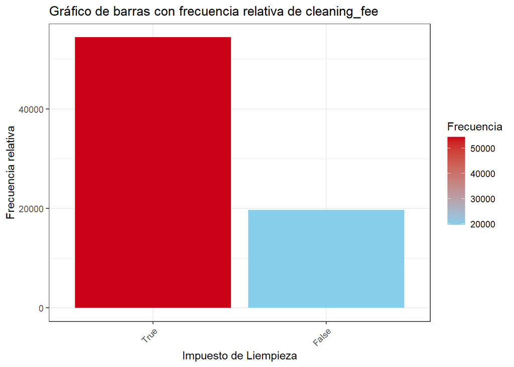

```r
Airbnb_Data  |> group_by(cleaning_fee) |>  summarise(Frequency = n()) |> mutate(cleaning_fee = reorder(cleaning_fee, -Frequency)) |> ggplot(aes(x = cleaning_fee, y = Frequency)) + geom_bar(stat = "identity", aes(fill = Frequency)) + theme_bw() + labs(title = "Gráfico de barras con frecuencia relativa de cleaning_fee", x = "Impuesto de Liempieza", y = "Frecuencia relativa") + scale_fill_gradient("Frecuencia", low = "skyblue", high = "#CB0019") + theme(axis.text.x = element_text(angle = 45, hjust = 1))
```

#### Estudio de la variable city

CONTAR EL NUMERO DE RESPUESTAS

```r
num_respuestas_city <- length(unique(Airbnb_Data$city))
cat("El número de respuestas obtenido es: ", num_respuestas_city)
```

```
## El número de respuestas obtenido es:  6
```

FRECUENCIAS RELATIVAS Y ABSOLUTAS

```r
tabla_frec_city <- Airbnb_Data |> count(city) |> mutate(f = n/nrow(Airbnb_Data), N = cumsum(n), F = cumsum(f))
tabla_frec_ord_8 <- tabla_frec_city |> arrange(desc(n))
tabla_frec_ord_8$N <- cumsum(tabla_frec_ord_8$n)
tabla_frec_ord_8$F <- cumsum(tabla_frec_ord_8$f)
print(tabla_frec_cleaning_fee)
```

[output not shown]

GRAFICO DE BARRAS CON FRECUENCIA RELATIVA

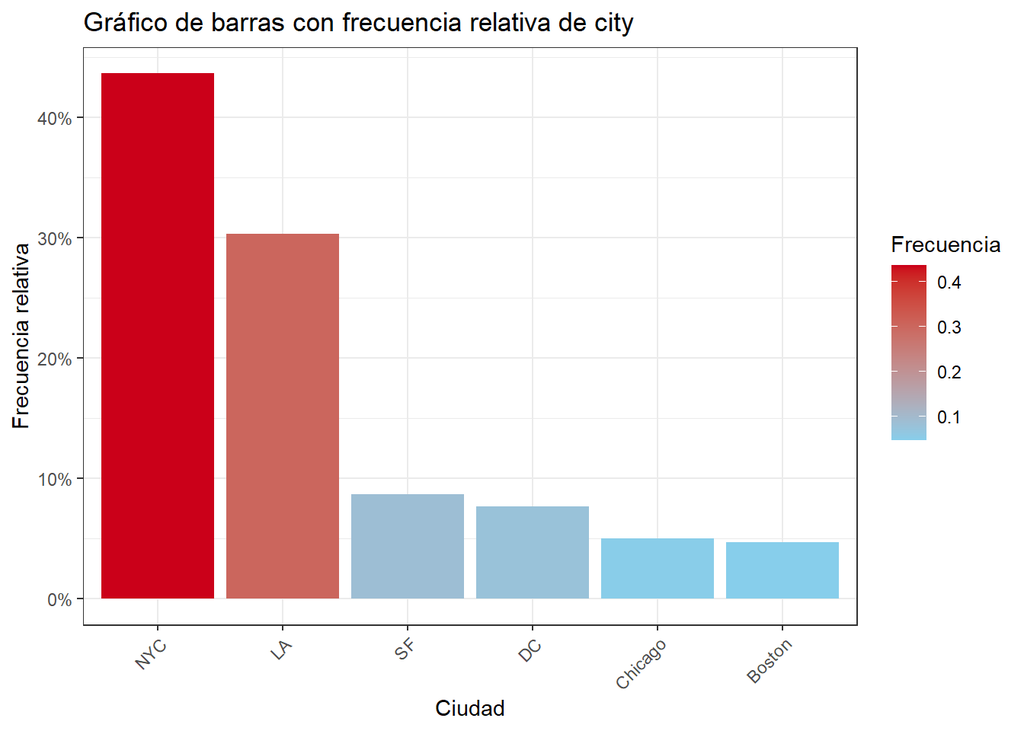

```r
Airbnb_Data  |> group_by(city) |>  summarise(Frequency = n()) |> mutate(Frequency = Frequency/sum(Frequency), city = reorder(city, -Frequency)) |> ggplot(aes(x = city, y = Frequency)) + geom_bar(stat = "identity", aes(fill = Frequency)) + scale_y_continuous(labels = scales::percent) + theme_bw() + labs(title = "Gráfico de barras con frecuencia relativa de city", x = "Ciudad", y = "Frecuencia relativa") + scale_fill_gradient("Frecuencia", low = "skyblue", high = "#CB0019") + theme(axis.text.x = element_text(angle = 45, hjust = 1))
```

GRAFICO DE BARRAS CON FRECUENCIA ABSOLUTA

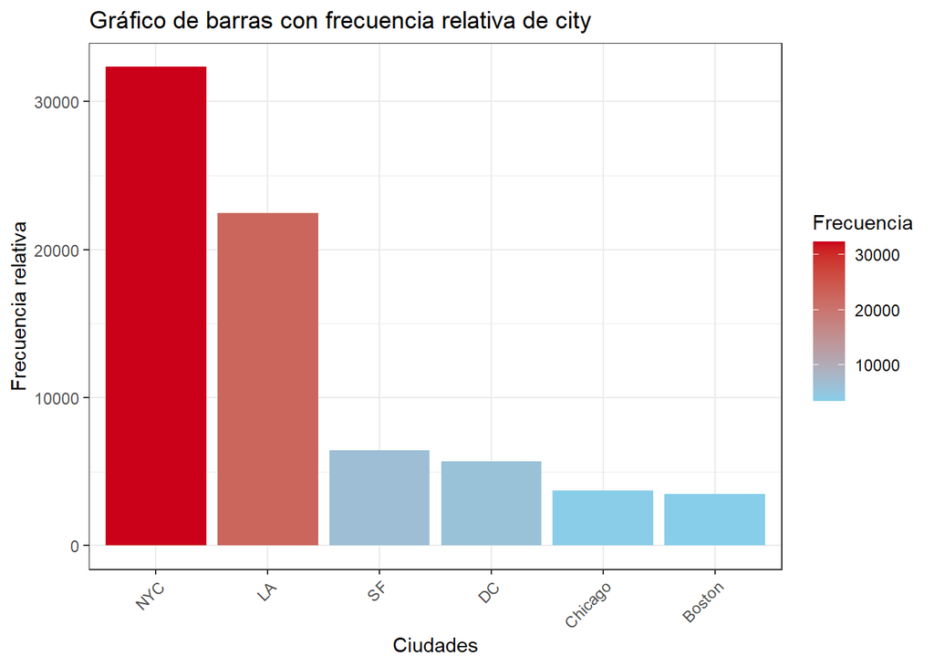

```r
Airbnb_Data  |> group_by(city) |>  summarise(Frequency = n()) |> mutate(city = reorder(city, -Frequency)) |> ggplot(aes(x = city, y = Frequency)) + geom_bar(stat = "identity", aes(fill = Frequency)) + theme_bw() + labs(title = "Gráfico de barras con frecuencia relativa de city", x = "Ciudades", y = "Frecuencia relativa") + scale_fill_gradient("Frecuencia", low = "skyblue", high = "#CB0019") + theme(axis.text.x = element_text(angle = 45, hjust = 1))
```

#### Estudio de la variable host_identity_verified

CONTAR EL NUMERO DE RESPUESTAS

```r
num_respuestas_host_identity_verified <- length(unique(Airbnb_Data$host_identity_verified))
cat("El número de respuestas obtenido es: ", num_respuestas_host_identity_verified)
```

```
## El número de respuestas obtenido es:  3
```

FRECUENCIAS RELATIVAS Y ABSOLUTAS

```r
tabla_frec_host_identity_verified <- Airbnb_Data |> count(Airbnb_Data$host_identity_verified) |> mutate(f = n/nrow(Airbnb_Data), N = cumsum(n), F = cumsum(f))
tabla_frec_ord_8 <- tabla_frec_host_identity_verified |> arrange(desc(n))
tabla_frec_ord_8$N <- cumsum(tabla_frec_ord_8$n)
tabla_frec_ord_8$F <- cumsum(tabla_frec_ord_8$f)
print(tabla_frec_host_identity_verified)
```

```
##   Airbnb_Data$host_identity_verified     n           f     N           F
## 1                                      188 0.002536735   188 0.002536735
## 2                                  f 24175 0.326199889 24363 0.328736625
## 3                                  t 49748 0.671263375 74111 1.000000000
```

GRAFICO DE BARRAS CON FRECUENCIA RELATIVA

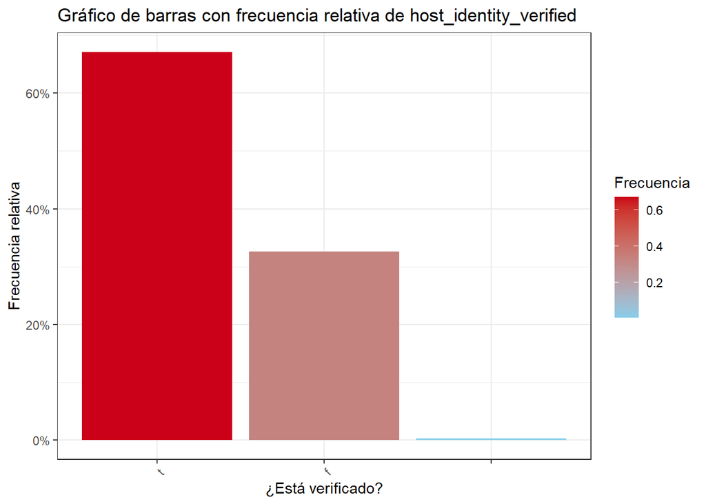

```r
Airbnb_Data  |> group_by(host_identity_verified) |>  summarise(Frequency = n()) |> mutate(Frequency = Frequency/sum(Frequency), host_identity_verified = reorder(host_identity_verified, -Frequency)) |> ggplot(aes(x = host_identity_verified, y = Frequency)) + geom_bar(stat = "identity", aes(fill = Frequency)) + scale_y_continuous(labels = scales::percent) + theme_bw() + labs(title = "Gráfico de barras con frecuencia relativa de host_identity_verified", x = "¿Está verificado?", y = "Frecuencia relativa") + scale_fill_gradient("Frecuencia", low = "skyblue", high = "#CB0019") + theme(axis.text.x = element_text(angle = 45, hjust = 1))
```

GRAFICO DE BARRAS CON FRECUENCIA ABSOLUTA

```r
table(Airbnb_Data$host_identity_verified)
```

```
##
##           f     t
##   188 24175 49748
```

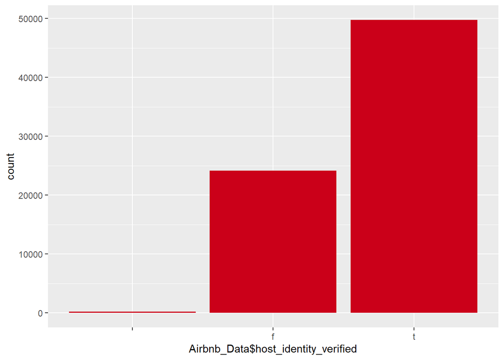

```r
Airbnb_Data |>
  ggplot(aes(Airbnb_Data$host_identity_verified)) +
  geom_bar(fill = "#CB0019")
```

#### Estudio de la variable instant_bookable

CONTAR EL NUMERO DE RESPUESTAS

```r
num_respuestas_instant_bookable <- length(unique(Airbnb_Data$instant_bookable))
cat("El número de respuestas obtenido es: ", num_respuestas_instant_bookable)
```

```
## El número de respuestas obtenido es:  2
```

FRECUENCIAS RELATIVAS Y ABSOLUTAS

```r
tabla_frec_instant_bookable <- Airbnb_Data |> count(Airbnb_Data$instant_bookable) |> mutate(f = n/nrow(Airbnb_Data), N = cumsum(n), F = cumsum(f))
tabla_frec_ord_8 <- tabla_frec_instant_bookable |> arrange(desc(n))
tabla_frec_ord_8$N <- cumsum(tabla_frec_ord_8$n)
tabla_frec_ord_8$F <- cumsum(tabla_frec_ord_8$f)
print(tabla_frec_instant_bookable)
```

```
##   Airbnb_Data$instant_bookable     n         f     N         F
## 1                            f 54660 0.7375423 54660 0.7375423
## 2                            t 19451 0.2624577 74111 1.0000000
```

GRAFICO DE BARRAS CON FRECUENCIA RELATIVA

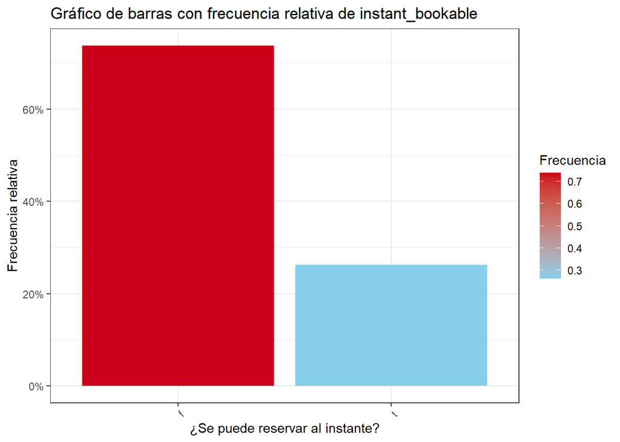

```r
Airbnb_Data  |> group_by(instant_bookable) |>  summarise(Frequency = n()) |> mutate(Frequency = Frequency/sum(Frequency), instant_bookable = reorder(instant_bookable, -Frequency)) |> ggplot(aes(x = instant_bookable, y = Frequency)) + geom_bar(stat = "identity", aes(fill = Frequency)) + scale_y_continuous(labels = scales::percent) + theme_bw() + labs(title = "Gráfico de barras con frecuencia relativa de instant_bookable", x = "¿Se puede reservar al instante?", y = "Frecuencia relativa") + scale_fill_gradient("Frecuencia", low = "skyblue", high = "#CB0019") + theme(axis.text.x = element_text(angle = 45, hjust = 1))
```

GRAFICO DE BARRAS CON FRECUENCIA ABSOLUTA

```r
table(Airbnb_Data$instant_bookable)
```

```
##
##     f     t
## 54660 19451
```

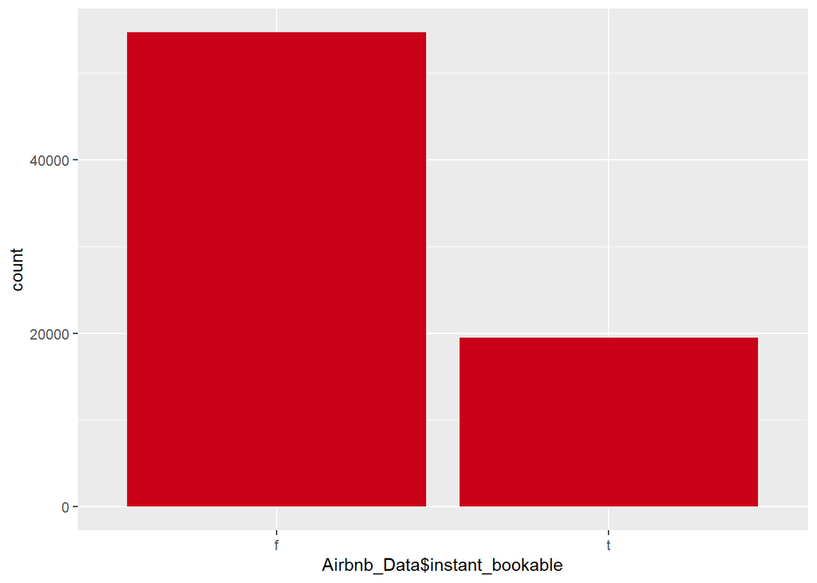

```r
Airbnb_Data |>
  ggplot(aes(Airbnb_Data$instant_bookable)) +
  geom_bar(fill = "#CB0019")
```

#### Estudio de la variable neighbourhood

CONTAR EL NUMERO DE RESPUESTAS

```r
num_respuestas_neighbourhood <- length(unique(Airbnb_Data$neighbourhood))
cat("El número de respuestas obtenido es: ", num_respuestas_neighbourhood)
```

```
## El número de respuestas obtenido es:  620
```

#### Estudio de la variable number_of_reviews

CONTAR EL NUMERO DE RESPUESTAS

```r
num_respuestas_number_of_reviews <- length(unique(Airbnb_Data$number_of_reviews))
cat("El número de respuestas obtenido es: ", num_respuestas_number_of_reviews)
```

```
## El número de respuestas obtenido es:  371
```

#### Estudio de la variable review_scores_rating

CONTAR EL NUMERO DE RESPUESTAS

```r
num_respuestas_review_scores_rating <- length(unique (Airbnb_Data$review_scores_rating))
cat("La cantidad de respuestas obtenidas es:", num_respuestas_review_scores_rating)
```

```
## La cantidad de respuestas obtenidas es: 55
```

FRECUENCIAS RELATIVAS Y ABSOLUTAS

```r
tabla_frecuencias_beds <- Airbnb_Data |>
     count(review_scores_rating) |>
     mutate(f = n / nrow(Airbnb_Data), N = cumsum(n), F = cumsum(f))
 tabla_frecuencias_ordenada4 <- tabla_frecuencias_beds |>
     arrange(desc(n))
 tabla_frecuencias_ordenada4$F <- cumsum(tabla_frecuencias_ordenada4$f)
 tabla_frecuencias_ordenada4$N <- cumsum(tabla_frecuencias_ordenada4$n)
 print(tabla_frecuencias_ordenada4)
```

```
##    review_scores_rating     n            f     N         F
## 1                    NA 16722 2.256345e-01 16722 0.2256345
## 2                   100 16215 2.187934e-01 32937 0.4444280
## 3                    98  4374 5.901958e-02 37311 0.5034475
## 4                    97  4087 5.514701e-02 41398 0.5585945
## 5                    96  4081 5.506605e-02 45479 0.6136606
## 6                    95  3713 5.010052e-02 49192 0.6637611
## 7                    93  3647 4.920997e-02 52839 0.7129711
## 8                    90  2852 3.848282e-02 55691 0.7514539
## 9                    99  2631 3.550080e-02 58322 0.7869547
## 10                   94  2618 3.532539e-02 60940 0.8222801
## 11                   80  2163 2.918595e-02 63103 0.8514660
## 12                   92  2064 2.785012e-02 65167 0.8793162
## 13                   91  1615 2.179164e-02 66782 0.9011078
## 14                   89  1120 1.511247e-02 67902 0.9162203
```

[output cut: 41 more lines]

GRAFICO DE BARRAS CON FRECUENCIA RELATIVA

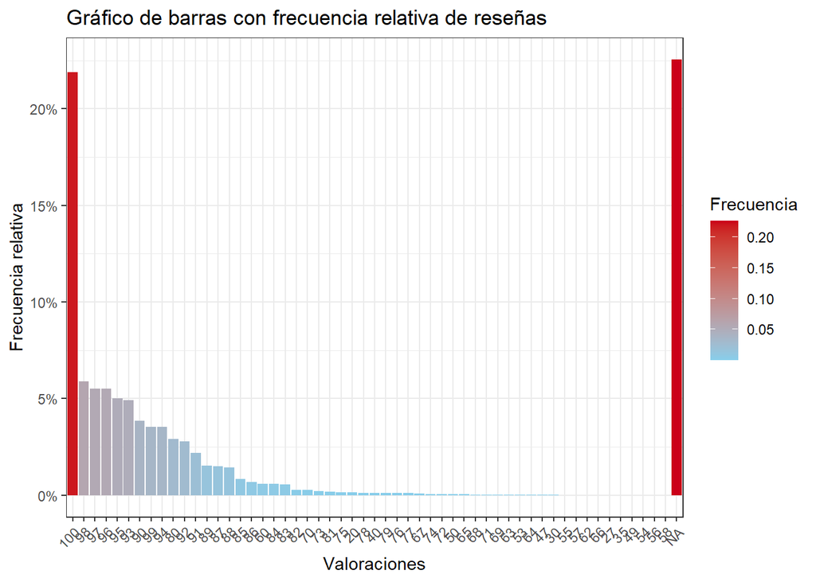

```r
Airbnb_Data  |> group_by(review_scores_rating) |>  summarise(Frequency = n()) |> mutate(Frequency = Frequency/sum(Frequency), review_scores_rating = reorder(review_scores_rating, -Frequency)) |> ggplot(aes(x = review_scores_rating, y = Frequency)) + geom_bar(stat = "identity", aes(fill = Frequency)) + scale_y_continuous(labels = scales::percent) + theme_bw() + labs(title = "Gráfico de barras con frecuencia relativa de reseñas", x = "Valoraciones", y = "Frecuencia relativa") + scale_fill_gradient("Frecuencia", low = "skyblue", high = "#CB0019") + theme(axis.text.x = element_text(angle = 45, hjust = 1))
```

GRAFICO DE BARRAS CON FRECUENCIA ABSOLUTA

[figure not shown]

```r
 datos <- Airbnb_Data$review_scores_rating
 ggplot(data.frame(x = datos), aes(x = x)) +
     geom_histogram(binwidth = 1, fill = "skyblue", color = "black",
                    aes(y = ..density..), alpha = 0.6) +
     stat_function(fun = dnorm, args = list(mean = mean(datos),
                                            sd = sd(datos)), color = "#CB0019", size = 1.5) +
     labs(title = "Distribución del Número de Habitaciones",
          x = "Número de Habitaciones",
          y = "Frecuencia")
```